# Supervised Learning : Exploring Robust Logistic Regression Models for Handling Quasi-Complete Separation

```r
max(FLIC_Model_Indices)
```

```
## [1] 8.10664
```

```r
min(FLIC_Model_Indices)
```

```
## [1] -8.077432
```

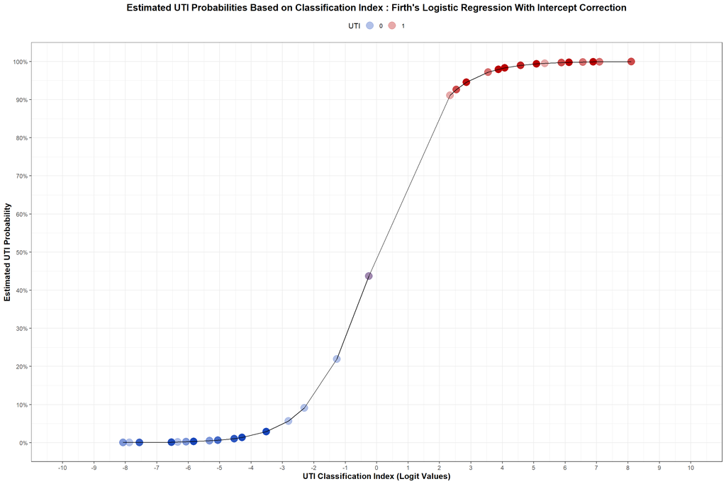

```r
##################################
# Consolidating the model probabilities
# and classification index
# based from the model predictions
##################################
FLIC_Model_Predictions <- as.data.frame(PMA_PreModelling_Train_FLIC)
FLIC_Model_Predictions$FLIC_Prob <- FLIC_Model_Probabilities
FLIC_Model_Predictions$FLIC_LP <- FLIC_Model_Indices
FLIC_Model_Predictions$UTI <- as.factor(FLIC_Model_Predictions$UTI)
FLIC_Model_Predictions$Label <- rep("FLIC",nrow(FLIC_Model_Predictions))

##################################
# Formulating the probability curve
# using the consolidated model predictions
##################################
FLIC_Model_Predictions %>%
  ggplot(aes(x = FLIC_LP ,
             y = FLIC_Prob,
             color = UTI)) +
  scale_colour_manual(values=c("#1846BA55","#B8000055")) +
  geom_point(size=5) +
  geom_line(color="black") +
  xlab("UTI Classification Index (Logit Values)") +
  ylab("Estimated UTI Probability") +
  labs(color = "UTI") +
  scale_x_continuous( limits=c(-10,10), breaks=seq(-10,10,by=1)) +
  scale_y_continuous( limits=c(0,1), breaks=seq(0,1,by=0.1),labels = scales::percent) +
  ggtitle("Estimated UTI Probabilities Based on Classification Index : Firth's Logistic Regression With Intercept Correction") +
  theme_bw() +
  theme(plot.title = element_text(color="black", size=14, face="bold", hjust=0.50),
        axis.title.x = element_text(color="black", size=12, face="bold"),
        axis.title.y = element_text(color="black", size=12, face="bold"),
        legend.position="top")
```

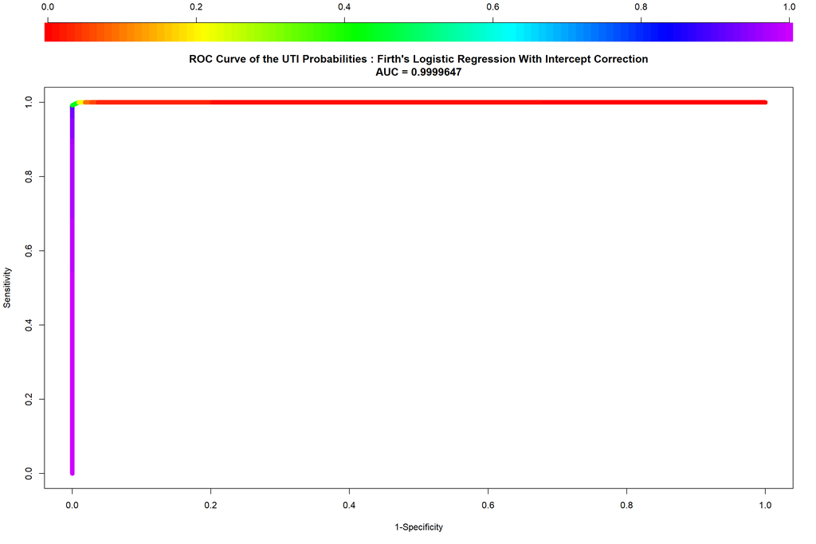

```r
##################################
# Formulating the corresponding
# receiver operating characteristic (ROC) curve
# using the model predictions
##################################
FLIC_Prob_Low  <- FLIC_Model_Predictions[FLIC_Model_Predictions$UTI==0,
                                    c("FLIC_Prob")]
FLIC_Prob_High <- FLIC_Model_Predictions[FLIC_Model_Predictions$UTI==1,
                                    c("FLIC_Prob")]
FLIC_Model_Prob_ROC <- roc.curve(scores.class1 = FLIC_Prob_Low,
                               scores.class0 = FLIC_Prob_High,
                                curve = TRUE)

plot(FLIC_Model_Prob_ROC,
     xlab="1-Specificity",
     ylab="Sensitivity",
     main="ROC Curve of the UTI Probabilities : Firth's Logistic Regression With Intercept Correction",
     color=TRUE,
     lwd=8,
     legend=3)
```

### 1.5.5 Bayesian Generalized Linear Model With Cauchy Priors (BGLM_CP)

**Code Chunk | Output**

```r
##################################
# Creating a local object
# for the train set
##################################
PMA_PreModelling_Train_BGLM_CP <- UTI

##################################
# Formulating the structure of the
# Bayesian Generalized Linear Model With Cauchy Priors model
##################################
BGLM_CP_Model <- bayesglm(UTI ~ Age_24 + Contraceptive + Condom + LubricatedCondom + Spermicide + Diaphragm,
                       data = PMA_PreModelling_Train_BGLM_CP,
                       family=binomial(link="logit"))

##################################
# Consolidating the model results
##################################
summary(BGLM_CP_Model)
```

```
##
## Call:
## bayesglm(formula = UTI ~ Age_24 + Contraceptive + Condom + LubricatedCondom +
##     Spermicide + Diaphragm, family = binomial(link = "logit"),
##     data = PMA_PreModelling_Train_BGLM_CP)
##
## Deviance Residuals:
##      Min        1Q    Median        3Q       Max
## -0.63151  -0.11668   0.02256   0.03135   1.84957
##
## Coefficients:
##                  Estimate Std. Error z value Pr(>|z|)
## (Intercept)        -3.051      1.924  -1.586    0.113
## Age_24             -0.489      1.753  -0.279    0.780
## Contraceptive      -1.935      1.797  -1.077    0.281
## Condom             -1.510      1.766  -0.855    0.392
## LubricatedCondom   -1.306      1.743  -0.750    0.453
## Spermicide          1.540      1.730   0.891    0.373
## Diaphragm          12.604      2.860   4.407 1.05e-05 ***
## ---
## Signif. codes:  0 '***' 0.001 '**' 0.01 '*' 0.05 '.' 0.1 ' ' 1
##
## (Dispersion parameter for binomial family taken to be 1)
##
##     Null deviance: 329.4768  on 238  degrees of freedom
## Residual deviance:   5.6929  on 232  degrees of freedom
## AIC: 19.693
##
## Number of Fisher Scoring iterations: 28
```

```r
BGLM_CP_Model_Coef <- (as.data.frame(BGLM_CP_Model$coefficients))
BGLM_CP_Model_Coef$Coef <- rownames(BGLM_CP_Model_Coef)
BGLM_CP_Model_Coef$Model <- rep("BGLM_CP",nrow(BGLM_CP_Model_Coef))
colnames(BGLM_CP_Model_Coef) <- c("Estimates","Coefficients","Model")
print(BGLM_CP_Model_Coef, rownames=FALSE)
```

```
##                   Estimates     Coefficients   Model
## (Intercept)      -3.0513140      (Intercept) BGLM_CP
## Age_24           -0.4890448           Age_24 BGLM_CP
## Contraceptive    -1.9351325    Contraceptive BGLM_CP
## Condom           -1.5103889           Condom BGLM_CP
## LubricatedCondom -1.3064324 LubricatedCondom BGLM_CP
## Spermicide        1.5402574       Spermicide BGLM_CP
## Diaphragm        12.6043657        Diaphragm BGLM_CP
```

```r
##################################
# Computing the model predictions
##################################
(BGLM_CP_Model_Probabilities <- predict(BGLM_CP_Model,
                              type = c("response")))
```

```
##            1            2            3            4            5            6
## 0.1807822594 0.9996786514 0.9996786514 0.9996786514 0.9996786514 0.9996786514
##            7            8            9           10           11           12
## 0.9996786514 0.9996786514 0.9996786514 0.9996786514 0.9996786514 0.9996786514
##           13           14           15           16           17           18
## 0.9996786514 0.9996786514 0.9996786514 0.9999311093 0.9999311093 0.9999311093
##           19           20           21           22           23           24
## 0.9988142938 0.9988142938 0.9988142938 0.9988142938 0.9988142938 0.9988142938
##           25           26           27           28           29           30
## 0.9988142938 0.9988142938 0.9988142938 0.9988142938 0.9997456355 0.9997456355
##           31           32           33           34           35           36
## 0.9997456355 0.9997456355 0.9997456355 0.9997456355 0.9997456355 0.9997456355
##           37           38           39           40           41           42
## 0.9997456355 0.9997456355 0.9997456355 0.9997456355 0.9997456355 0.9995086779
##           43           44           45           46           47           48
## 0.9995086779 0.9995086779 0.9995086779 0.9995086779 0.9995086779 0.9995086779
##           49           50           51           52           53           54
## 0.9995086779 0.9995086779 0.9995086779 0.9995086779 0.9995086779 0.9995086779
##           55           56           57           58           59           60
## 0.9995086779 0.9995086779 0.9995086779 0.9995086779 0.9995086779 0.9995086779
##           61           62           63           64           65           66
## 0.9995086779 0.9995086779 0.9995086779 0.9995086779 0.9995086779 0.9995086779
##           67           68           69           70           71           72
## 0.9995086779 0.9995086779 0.9995086779 0.9995086779 0.9995086779 0.9995086779
##           73           74           75           76           77           78
## 0.9995086779 0.9995086779 0.9995086779 0.9995086779 0.9995086779 0.9995086779
##           79           80           81           82           83           84
## 0.9995086779 0.9995086779 0.9995086779 0.9995086779 0.9995086779 0.9995086779
##           85           86           87           88           89           90
## 0.9995086779 0.9995086779 0.9995086779 0.9995086779 0.9977789026 0.9977789026
##           91           92           93           94           95           96
## 0.9977789026 0.9977789026 0.9977789026 0.9977789026 0.9977789026 0.9977789026
##           97           98           99          100          101          102
## 0.9977789026 0.9977789026 0.9977789026 0.9977789026 0.9977789026 0.9977789026
##          103          104          105          106          107          108
## 0.9977789026 0.9977789026 0.9995231291 0.9995231291 0.9918463122 0.9918463122
##          109          110          111          112          113          114
## 0.9918463122 0.9918463122 0.9918463122 0.9918463122 0.9918463122 0.9982411861
##          115          116          117          118          119          120
## 0.9982411861 0.9982411861 0.9994760645 0.9994760645 0.9998876608 0.9998876608
```

[output cut: 25 more lines]

```
## 0.0067835607 0.0067835607 0.0067835607 0.0067835607 0.0067835607 0.0067835607
##          199          200          201          202          203          204
## 0.0067835607 0.0067835607 0.0067835607 0.0067835607 0.0308827134 0.0015059333
##          205          206          207          208          209          210
## 0.0004082315 0.0004082315 0.0004082315 0.0004082315 0.0004082315 0.0019018768
##          211          212          213          214          215          216
## 0.0019018768 0.0019018768 0.0019018768 0.0019018768 0.0019018768 0.0017312477
##          217          218          219          220          221          222
## 0.0017312477 0.0080266998 0.0080266998 0.0080266998 0.0080266998 0.0041707030
##          223          224          225          226          227          228
## 0.0041707030 0.0041707030 0.0041707030 0.0041707030 0.0041707030 0.0041707030
##          229          230          231          232          233          234
## 0.0041707030 0.0041707030 0.0041707030 0.0041707030 0.0041707030 0.0041707030
##          235          236          237          238          239
## 0.0041707030 0.0191665924 0.0009239944 0.0011671120 0.0011671120
```

```r
##################################
# Creating a classification index
# based from the model predictions
##################################
(BGLM_CP_Model_Indices <- predict(BGLM_CP_Model,
                           type = c("link")))
```

```
##         1         2         3         4         5         6         7         8
## -1.511057  8.042663  8.042663  8.042663  8.042663  8.042663  8.042663  8.042663
##         9        10        11        12        13        14        15        16
##  8.042663  8.042663  8.042663  8.042663  8.042663  8.042663  8.042663  9.582920
##        17        18        19        20        21        22        23        24
##  9.582920  9.582920  6.736230  6.736230  6.736230  6.736230  6.736230  6.736230
##        25        26        27        28        29        30        31        32
##  6.736230  6.736230  6.736230  6.736230  8.276488  8.276488  8.276488  8.276488
##        33        34        35        36        37        38        39        40
##  8.276488  8.276488  8.276488  8.276488  8.276488  8.276488  8.276488  8.276488
##        41        42        43        44        45        46        47        48
##  8.276488  7.617919  7.617919  7.617919  7.617919  7.617919  7.617919  7.617919
##        49        50        51        52        53        54        55        56
##  7.617919  7.617919  7.617919  7.617919  7.617919  7.617919  7.617919  7.617919
##        57        58        59        60        61        62        63        64
##  7.617919  7.617919  7.617919  7.617919  7.617919  7.617919  7.617919  7.617919
##        65        66        67        68        69        70        71        72
##  7.617919  7.617919  7.617919  7.617919  7.617919  7.617919  7.617919  7.617919
##        73        74        75        76        77        78        79        80
##  7.617919  7.617919  7.617919  7.617919  7.617919  7.617919  7.617919  7.617919
##        81        82        83        84        85        86        87        88
##  7.617919  7.617919  7.617919  7.617919  7.617919  7.617919  7.617919  7.617919
##        89        90        91        92        93        94        95        96
##  6.107530  6.107530  6.107530  6.107530  6.107530  6.107530  6.107530  6.107530
##        97        98        99       100       101       102       103       104
##  6.107530  6.107530  6.107530  6.107530  6.107530  6.107530  6.107530  6.107530
##       105       106       107       108       109       110       111       112
##  7.647788  7.647788  4.801098  4.801098  4.801098  4.801098  4.801098  4.801098
##       113       114       115       116       117       118       119       120
##  4.801098  6.341355  6.341355  6.341355  7.553618  7.553618  9.093875  9.093875
##       121       122       123       124       125       126       127       128
##  6.247186  7.787443  7.128874  7.128874  7.128874  7.128874  7.128874  5.618486
##       129       130       131       132       133       134       135       136
##  5.618486  5.618486 -1.511057 -4.561703 -4.561703 -3.021446 -5.868135 -5.868135
##       137       138       139       140       141       142       143       144
## -5.868135 -5.868135 -5.868135 -5.868135 -5.868135 -5.868135 -4.327878 -4.327878
##       145       146       147       148       149       150       151       152
## -4.327878 -4.327878 -4.327878 -4.327878 -4.327878 -4.327878 -4.327878 -4.327878
##       153       154       155       156       157       158       159       160
## -4.327878 -4.327878 -4.327878 -4.327878 -4.327878 -4.327878 -4.327878 -4.327878
##       161       162       163       164       165       166       167       168
## -4.986446 -4.986446 -4.986446 -4.986446 -4.986446 -4.986446 -4.986446 -4.986446
##       169       170       171       172       173       174       175       176
## -4.986446 -4.986446 -4.986446 -4.986446 -4.986446 -4.986446 -4.986446 -4.986446
##       177       178       179       180       181       182       183       184
## -4.986446 -4.986446 -4.986446 -4.986446 -4.986446 -4.986446 -4.986446 -4.986446
##       185       186       187       188       189       190       191       192
## -4.986446 -4.986446 -4.986446 -4.986446 -4.986446 -4.986446 -4.986446 -4.986446
##       193       194       195       196       197       198       199       200
## -4.986446 -4.986446 -4.986446 -4.986446 -4.986446 -4.986446 -4.986446 -4.986446
##       201       202       203       204       205       206       207       208
## -4.986446 -4.986446 -3.446189 -6.496835 -7.803268 -7.803268 -7.803268 -7.803268
##       209       210       211       212       213       214       215       216
## -7.803268 -6.263010 -6.263010 -6.263010 -6.263010 -6.263010 -6.263010 -6.357180
##       217       218       219       220       221       222       223       224
## -6.357180 -4.816923 -4.816923 -4.816923 -4.816923 -5.475491 -5.475491 -5.475491
##       225       226       227       228       229       230       231       232
## -5.475491 -5.475491 -5.475491 -5.475491 -5.475491 -5.475491 -5.475491 -5.475491
##       233       234       235       236       237       238       239
## -5.475491 -5.475491 -5.475491 -3.935234 -6.985880 -6.752055 -6.752055
```

```r
max(BGLM_CP_Model_Indices)
```

```
## [1] 9.58292
```

```r
min(BGLM_CP_Model_Indices)
```

```
## [1] -7.803268
```

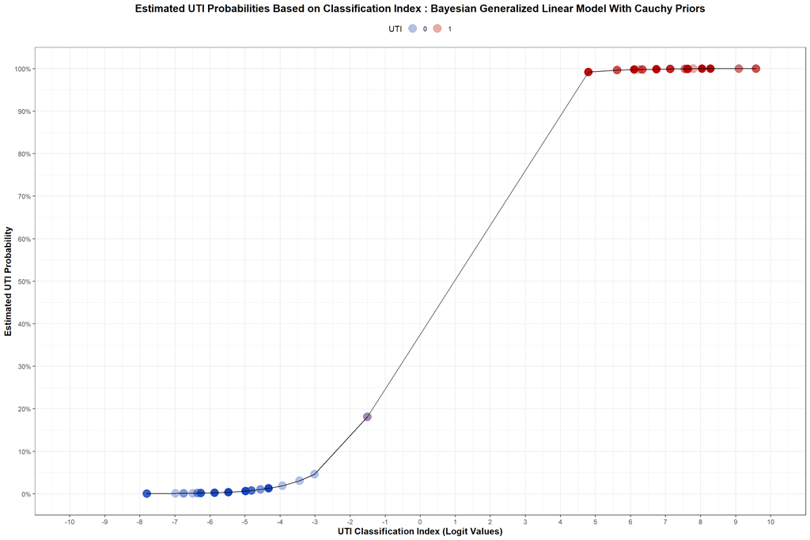

```r
##################################
# Consolidating the model probabilities
# and classification index
# based from the model predictions
##################################
BGLM_CP_Model_Predictions <- as.data.frame(PMA_PreModelling_Train_BGLM_CP)
BGLM_CP_Model_Predictions$BGLM_CP_Prob <- BGLM_CP_Model_Probabilities
BGLM_CP_Model_Predictions$BGLM_CP_LP <- BGLM_CP_Model_Indices
BGLM_CP_Model_Predictions$UTI <- as.factor(BGLM_CP_Model_Predictions$UTI)
BGLM_CP_Model_Predictions$Label <- rep("BGLM_CP",nrow(BGLM_CP_Model_Predictions))

##################################
# Formulating the probability curve
# using the consolidated model predictions
##################################
BGLM_CP_Model_Predictions %>%
  ggplot(aes(x = BGLM_CP_LP ,
             y = BGLM_CP_Prob,
             color = UTI)) +
  scale_colour_manual(values=c("#1846BA55","#B8000055")) +
  geom_point(size=5) +
  geom_line(color="black") +
  xlab("UTI Classification Index (Logit Values)") +
  ylab("Estimated UTI Probability") +
  labs(color = "UTI") +
  scale_x_continuous( limits=c(-10,10), breaks=seq(-10,10,by=1)) +
  scale_y_continuous( limits=c(0,1), breaks=seq(0,1,by=0.1),labels = scales::percent) +
  ggtitle("Estimated UTI Probabilities Based on Classification Index : Bayesian Generalized Linear Model With Cauchy Priors") +
  theme_bw() +
  theme(plot.title = element_text(color="black", size=14, face="bold", hjust=0.50),
        axis.title.x = element_text(color="black", size=12, face="bold"),
        axis.title.y = element_text(color="black", size=12, face="bold"),
        legend.position="top")
```

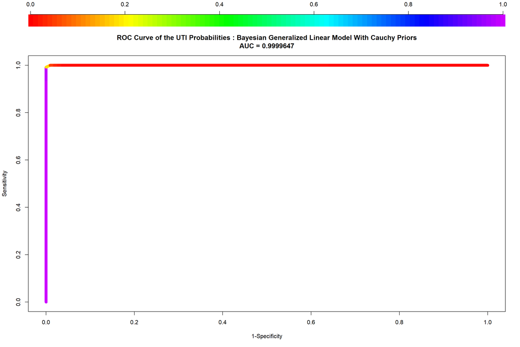

```r
##################################
# Formulating the corresponding
# receiver operating characteristic (ROC) curve
# using the model predictions
##################################
BGLM_CP_Prob_Low  <- BGLM_CP_Model_Predictions[BGLM_CP_Model_Predictions$UTI==0,
                                    c("BGLM_CP_Prob")]
BGLM_CP_Prob_High <- BGLM_CP_Model_Predictions[BGLM_CP_Model_Predictions$UTI==1,
                                    c("BGLM_CP_Prob")]
BGLM_CP_Model_Prob_ROC <- roc.curve(scores.class1 = BGLM_CP_Prob_Low,
                               scores.class0 = BGLM_CP_Prob_High,
                                curve = TRUE)

plot(BGLM_CP_Model_Prob_ROC,
     xlab="1-Specificity",
     ylab="Sensitivity",
     main="ROC Curve of the UTI Probabilities : Bayesian Generalized Linear Model With Cauchy Priors",
     color=TRUE,
     lwd=8,
     legend=3)
```

### 1.5.6 Penalized Logistic Regression - Ridge (PLR_R)

[Ridge Penalized Logistic Regression](https://www.tandfonline.com/doi/abs/10.1080/00401706.1970.10488634) implements a shrinkage estimation method to deal with infinite estimates by pulling, on average, the original estimates towards zero. The algorithm penalizes the log-likelihood by subtracting a multiple of the sum of the squared coefficients while excluding the intercept from the sum, which is equivalent to penalization using normal prior densities.  
**[A]** The penalized logistic regression - ridge model from the **glmnet** package was implemented. The UTI response was regressed against the Age_24, Contraceptive, Condom, LubricatedCondom, Spermicide and Diaphragm predictors.  
**[B]** The model contains 1 hyperparameter:  
**[B.1]** lambda = shrinkage parameter made to vary across a range of values equal to 0.05 to 490  
**[C]** The model was able to sufficiently compensate for the quasi-complete condition simulated for the Diaphragm predictor, resulting in reasonably valid estimated coefficients and standard errors.  
**[C.1]** Intercept coefficient = -1.719  
**[C.2]** Age_24 coefficient = -0.363  
**[C.3]** Contraceptive coefficient = -0.185  
**[C.4]** Condom coefficient = +0.324  
**[C.5]** LubricatedCondom coefficient = -0.472  
**[C.6]** Spermicide coefficient = -0.149  
**[C.7]** Diaphragm coefficient = +4.129  
**[D]** The logistic curve formulated by plotting the predicted probabilities against the classification index using the logit values showed a a slightly kinked logistic profile with reasonably distributed predicted points.  
**[E]** The performance of the model is summarized as follows:  
**[E.1]** Final model configuration involves lambda=0.05.  
**[E.2]** Apparent ROC Curve AUC = 0.99912  
**[E.3]** Estimated probabilities were reasonably distributed across a range of values.

**Code Chunk | Output**

```r
##################################
# Creating a local object
# for the train set
##################################
PMA_PreModelling_Train_PLR_R <- UTI
PLR_R_Response   <- PMA_PreModelling_Train_PLR_R[,c("UTI")]
PLR_R_Predictors <- model.matrix(UTI~.,
                                  PMA_PreModelling_Train_PLR_R)[,2:ncol(PMA_PreModelling_Train_PLR_R)]

##################################
# Conducting hyperparameter tuning
# of the lambda parameter
# using cross-validation
##################################
(PLR_R_LambdaCV <- cv.glmnet(PLR_R_Predictors,
                            PLR_R_Response,
                            family = "binomial",
                            alpha = 0))
```

```
##
## Call:  cv.glmnet(x = PLR_R_Predictors, y = PLR_R_Response, family = "binomial",      alpha = 0)
##
## Measure: Binomial Deviance
##
##      Lambda Index Measure      SE Nonzero
## min 0.04939   100  0.2466 0.01868       6
## 1se 0.05420    99  0.2605 0.01817       6
```

```r
PLR_R_LambdaCV$lambda
```

```
##   [1] 493.88644807 450.01093723 410.03320585 373.60698594 340.41677102
##   [6] 310.17508331 282.61998378 257.51280336 234.63607564 213.79165337
##  [11] 194.79899212 177.49358655 161.72554551 147.35829378 134.26738910
##  [16] 122.33944431 111.47114526 101.56835594  92.54530313  84.32383347
##  [21]  76.83273651  70.00712796  63.78788766  58.12114752  52.95782497
##  [26]  48.25319775  43.96651666  40.06065249  36.50177454  33.25905749
##  [31]  30.30441449  27.61225383  25.15925730  22.92417822  20.88765741
##  [36]  19.03205550  17.34130014  15.80074683  14.39705203  13.11805761
##  [41]  11.95268553  10.89084189   9.92332951   9.04176827   8.23852249
##  [46]   7.50663486   6.83976611   6.23214014   5.67849399   5.17403223
##  [51]   4.71438547   4.29557246   3.91396564   3.56625972   3.24944303
##  [56]   2.96077147   2.69774469   2.45808449   2.23971504   2.04074493
##  [61]   1.85945077   1.69426229   1.54374870   1.40660632   1.28164729
##  [66]   1.16778928   1.06404610   0.96951917   0.88338976   0.80491185
##  [71]   0.73340570   0.66825196   0.60888630   0.55479452   0.50550810
##  [76]   0.46060015   0.41968171   0.38239834   0.34842713   0.31747382
##  [81]   0.28927032   0.26357234   0.24015730   0.21882239   0.19938281
##  [86]   0.18167019   0.16553111   0.15082579   0.13742684   0.12521822
##  [91]   0.11409418   0.10395836   0.09472299   0.08630806   0.07864069
##  [96]   0.07165447   0.06528888   0.05948880   0.05420398   0.04938864
```

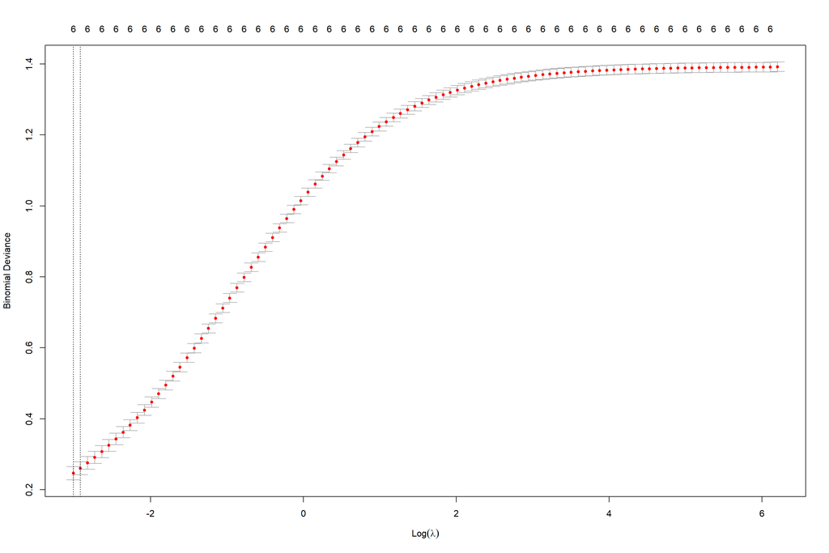

```r
plot(PLR_R_LambdaCV)
```

```r
(PLR_R_MinLambda <- PLR_R_LambdaCV$lambda.min)
```

```
## [1] 0.04938864
```

```r
##################################
# Formulating the structure of the
# Penalized Logistic Regression - Ridge model
##################################
PLR_R_Model <- glmnet(PLR_R_Predictors,
                      PLR_R_Response,
                      alpha = 0,
                      family = "binomial",
                      lambda = PLR_R_MinLambda)

##################################
# Consolidating the model results
##################################
summary(PLR_R_Model)
```

```
##            Length Class     Mode
## a0         1      -none-    numeric
## beta       6      dgCMatrix S4
## df         1      -none-    numeric
## dim        2      -none-    numeric
## lambda     1      -none-    numeric
## dev.ratio  1      -none-    numeric
## nulldev    1      -none-    numeric
## npasses    1      -none-    numeric
## jerr       1      -none-    numeric
## offset     1      -none-    logical
## classnames 2      -none-    character
## call       6      -none-    call
## nobs       1      -none-    numeric
```

```r
coef(PLR_R_Model)
```

```
## 7 x 1 sparse Matrix of class "dgCMatrix"
##                          s0
## (Intercept)      -1.7196340
## Age_24           -0.3633108
## Contraceptive    -0.1858195
## Condom            0.3240962
## LubricatedCondom -0.4720128
## Spermicide       -0.1491506
## Diaphragm         4.1293922
```

```r
PLR_R_Model_Coef <- (as.data.frame(coef(PLR_R_Model)[1:7]))
PLR_R_Model_Coef$Coef <- rownames(coef(PLR_R_Model))
PLR_R_Model_Coef$Model <- rep("PLR_R",nrow(PLR_R_Model_Coef))
colnames(PLR_R_Model_Coef) <- c("Estimates","Coefficients","Model")
print(PLR_R_Model_Coef, rownames=FALSE)
```

```
##    Estimates     Coefficients Model
## 1 -1.7196340      (Intercept) PLR_R
## 2 -0.3633108           Age_24 PLR_R
## 3 -0.1858195    Contraceptive PLR_R
## 4  0.3240962           Condom PLR_R
## 5 -0.4720128 LubricatedCondom PLR_R
## 6 -0.1491506       Spermicide PLR_R
## 7  4.1293922        Diaphragm PLR_R
```

```r
##################################
# Computing the model predictions
##################################
(PLR_R_Model_Probabilities <- PLR_R_Model %>%
   predict(PLR_R_Predictors, type = c("response")) %>%
   as.vector())
```

```
##   [1] 0.13368241 0.93899500 0.93899500 0.93899500 0.93899500 0.93899500
##   [7] 0.93899500 0.93899500 0.93899500 0.93899500 0.93899500 0.93899500
##  [13] 0.93899500 0.93899500 0.93899500 0.92987063 0.92987063 0.92987063
##  [19] 0.90566709 0.90566709 0.90566709 0.90566709 0.90566709 0.90566709
##  [25] 0.90566709 0.90566709 0.90566709 0.90566709 0.89213057 0.89213057
##  [31] 0.89213057 0.89213057 0.89213057 0.89213057 0.89213057 0.89213057
##  [37] 0.89213057 0.89213057 0.89213057 0.89213057 0.89213057 0.90237871
##  [43] 0.90237871 0.90237871 0.90237871 0.90237871 0.90237871 0.90237871
##  [49] 0.90237871 0.90237871 0.90237871 0.90237871 0.90237871 0.90237871
##  [55] 0.90237871 0.90237871 0.90237871 0.90237871 0.90237871 0.90237871
##  [61] 0.90237871 0.90237871 0.90237871 0.90237871 0.90237871 0.90237871
##  [67] 0.90237871 0.90237871 0.90237871 0.90237871 0.90237871 0.90237871
##  [73] 0.90237871 0.90237871 0.90237871 0.90237871 0.90237871 0.90237871
##  [79] 0.90237871 0.90237871 0.90237871 0.90237871 0.90237871 0.90237871
##  [85] 0.90237871 0.90237871 0.90237871 0.90237871 0.92744138 0.92744138
```

[output cut: 25 more lines]

```r
##################################
# Creating a classification index
# based from the model predictions
##################################
(PLR_R_Model_Indices <- PLR_R_Model %>%
   predict(PLR_R_Predictors, type = c("link")) %>%
   as.vector())
```

```
##   [1] -1.868785  2.733854  2.733854  2.733854  2.733854  2.733854  2.733854
##   [8]  2.733854  2.733854  2.733854  2.733854  2.733854  2.733854  2.733854
##  [15]  2.733854  2.584704  2.584704  2.584704  2.261842  2.261842  2.261842
##  [22]  2.261842  2.261842  2.261842  2.261842  2.261842  2.261842  2.261842
##  [29]  2.112691  2.112691  2.112691  2.112691  2.112691  2.112691  2.112691
##  [36]  2.112691  2.112691  2.112691  2.112691  2.112691  2.112691  2.223939
##  [43]  2.223939  2.223939  2.223939  2.223939  2.223939  2.223939  2.223939
##  [50]  2.223939  2.223939  2.223939  2.223939  2.223939  2.223939  2.223939
##  [57]  2.223939  2.223939  2.223939  2.223939  2.223939  2.223939  2.223939
##  [64]  2.223939  2.223939  2.223939  2.223939  2.223939  2.223939  2.223939
##  [71]  2.223939  2.223939  2.223939  2.223939  2.223939  2.223939  2.223939
##  [78]  2.223939  2.223939  2.223939  2.223939  2.223939  2.223939  2.223939
##  [85]  2.223939  2.223939  2.223939  2.223939  2.548035  2.548035  2.548035
##  [92]  2.548035  2.548035  2.548035  2.548035  2.548035  2.548035  2.548035
##  [99]  2.548035  2.548035  2.548035  2.548035  2.548035  2.548035  2.398884
```

[output cut: 20 more lines]

```r
max(PLR_R_Model_Indices)
```

```
## [1] 2.733854
```

```r
min(PLR_R_Model_Indices)
```

```
## [1] -2.565832
```

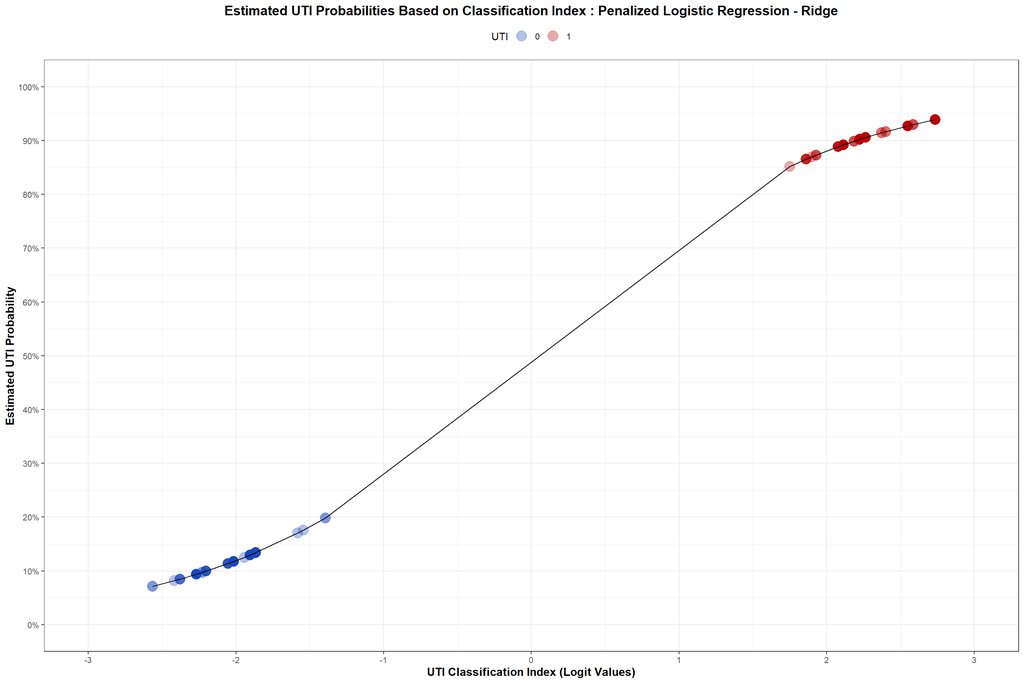

```r
##################################
# Consolidating the model probabilities
# and classification index
# based from the model predictions
##################################
PLR_R_Model_Predictions <- as.data.frame(PMA_PreModelling_Train_PLR_R)
PLR_R_Model_Predictions$PLR_R_Prob <- PLR_R_Model_Probabilities
PLR_R_Model_Predictions$PLR_R_LP <- PLR_R_Model_Indices
PLR_R_Model_Predictions$UTI <- as.factor(PLR_R_Model_Predictions$UTI)
PLR_R_Model_Predictions$Label <- rep("PLR_R",nrow(PLR_R_Model_Predictions))

##################################
# Formulating the probability curve
# using the consolidated model predictions
##################################
PLR_R_Model_Predictions %>%
  ggplot(aes(x = PLR_R_LP ,
             y = PLR_R_Prob,
             color = UTI)) +
  scale_colour_manual(values=c("#1846BA55","#B8000055")) +
  geom_point(size=5) +
  geom_line(color="black") +
  xlab("UTI Classification Index (Logit Values)") +
  ylab("Estimated UTI Probability") +
  labs(color = "UTI") +
  scale_x_continuous( limits=c(-3,3), breaks=seq(-3,3,by=1)) +
  scale_y_continuous( limits=c(0,1), breaks=seq(0,1,by=0.1),labels = scales::percent) +
  ggtitle("Estimated UTI Probabilities Based on Classification Index : Penalized Logistic Regression - Ridge") +
  theme_bw() +
  theme(plot.title = element_text(color="black", size=14, face="bold", hjust=0.50),
        axis.title.x = element_text(color="black", size=12, face="bold"),
        axis.title.y = element_text(color="black", size=12, face="bold"),
        legend.position="top")
```

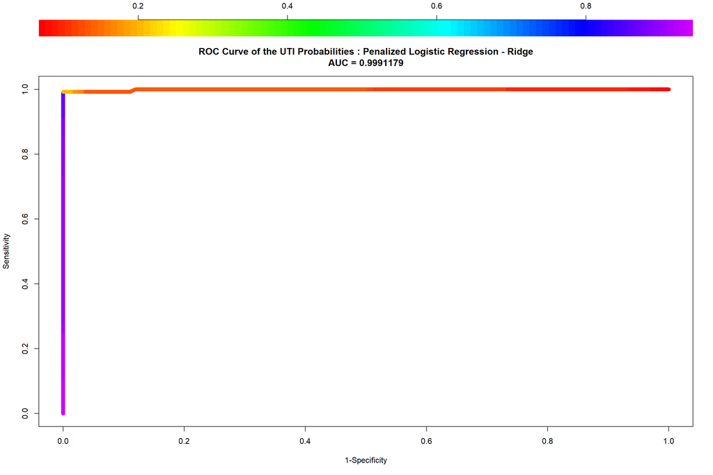

```r
##################################
# Formulating the corresponding
# receiver operating characteristic (ROC) curve
# using the model predictions
##################################
PLR_R_Prob_Low  <- PLR_R_Model_Predictions[PLR_R_Model_Predictions$UTI==0,
                                    c("PLR_R_Prob")]
PLR_R_Prob_High <- PLR_R_Model_Predictions[PLR_R_Model_Predictions$UTI==1,
                                    c("PLR_R_Prob")]
PLR_R_Model_Prob_ROC <- roc.curve(scores.class1 = PLR_R_Prob_Low,
                               scores.class0 = PLR_R_Prob_High,
                                curve = TRUE)

plot(PLR_R_Model_Prob_ROC,
     xlab="1-Specificity",
     ylab="Sensitivity",
     main="ROC Curve of the UTI Probabilities : Penalized Logistic Regression - Ridge",
     color=TRUE,
     lwd=8,
     legend=3)
```

## 1.6 Consolidated Findings

**Code Chunk | Output**

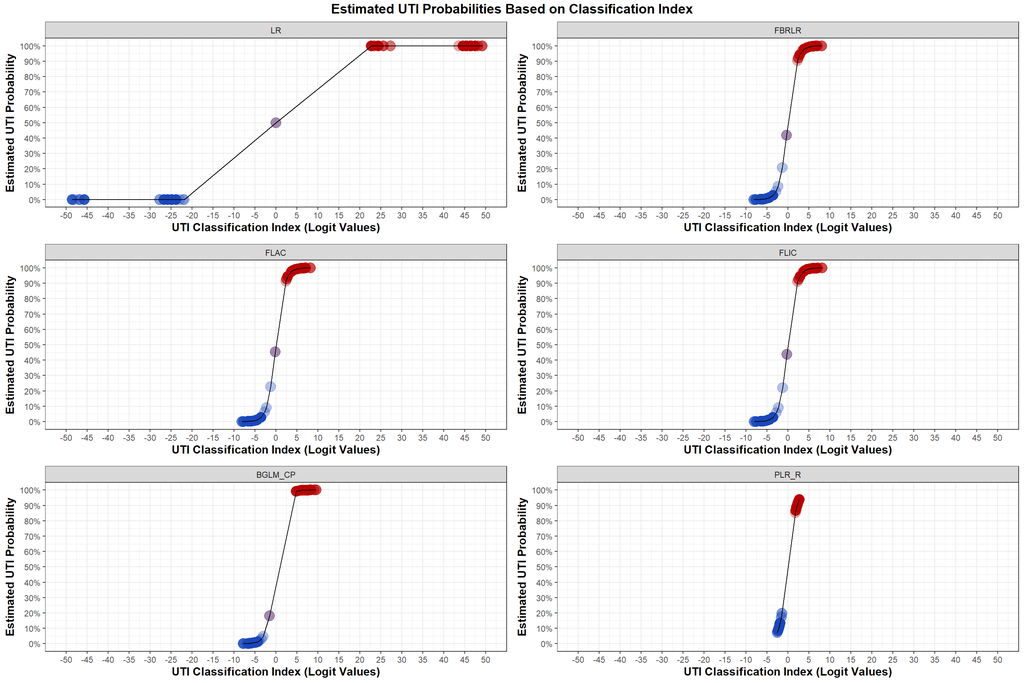

```r
##################################
# Replotting the logistic curves
##################################
LR_LogisticCurvePlot <- LR_Model_Predictions %>%
  ggplot(aes(x = LR_LP ,
             y = LR_Prob,
             color = UTI)) +
  scale_colour_manual(values=c("#1846BA55","#B8000055")) +
  geom_point(size=5) +
  geom_line(color="black") +
  xlab("UTI Classification Index (Logit Values)") +
  ylab("Estimated UTI Probability") +
  labs(color = "UTI") +
  scale_x_continuous( limits=c(-50,50), breaks=seq(-50,50,by=5)) +
  scale_y_continuous( limits=c(0,1), breaks=seq(0,1,by=0.1),labels = scales::percent) +
  facet_grid(. ~ Label) +
  theme_bw() +
  theme(plot.title = element_text(color="black", size=14, face="bold", hjust=0.50),
        axis.title.x = element_text(color="black", size=12, face="bold"),
        axis.title.y = element_text(color="black", size=12, face="bold"),
        legend.position="none")

FBRLR_LogisticCurvePlot <- FBRLR_Model_Predictions %>%
  ggplot(aes(x = FBRLR_LP ,
             y = FBRLR_Prob,
             color = UTI)) +
  scale_colour_manual(values=c("#1846BA55","#B8000055")) +
  geom_point(size=5) +
  geom_line(color="black") +
  xlab("UTI Classification Index (Logit Values)") +
  ylab("Estimated UTI Probability") +
  labs(color = "UTI") +
  scale_x_continuous( limits=c(-50,50), breaks=seq(-50,50,by=5)) +
  scale_y_continuous( limits=c(0,1), breaks=seq(0,1,by=0.1),labels = scales::percent) +
  facet_grid(. ~ Label) +
  theme_bw() +
  theme(plot.title = element_text(color="black", size=14, face="bold", hjust=0.50),
        axis.title.x = element_text(color="black", size=12, face="bold"),
        axis.title.y = element_text(color="black", size=12, face="bold"),
        legend.position="none")

FLAC_LogisticCurvePlot <- FLAC_Model_Predictions %>%
  ggplot(aes(x = FLAC_LP ,
             y = FLAC_Prob,
             color = UTI)) +
  scale_colour_manual(values=c("#1846BA55","#B8000055")) +
  geom_point(size=5) +
  geom_line(color="black") +
  xlab("UTI Classification Index (Logit Values)") +
  ylab("Estimated UTI Probability") +
  labs(color = "UTI") +
  scale_x_continuous( limits=c(-50,50), breaks=seq(-50,50,by=5)) +
  scale_y_continuous( limits=c(0,1), breaks=seq(0,1,by=0.1),labels = scales::percent) +
  facet_grid(. ~ Label) +
  theme_bw() +
  theme(plot.title = element_text(color="black", size=14, face="bold", hjust=0.50),
        axis.title.x = element_text(color="black", size=12, face="bold"),
        axis.title.y = element_text(color="black", size=12, face="bold"),
        legend.position="none")

FLIC_LogisticCurvePlot <- FLIC_Model_Predictions %>%
  ggplot(aes(x = FLIC_LP ,
             y = FLIC_Prob,
             color = UTI)) +
  scale_colour_manual(values=c("#1846BA55","#B8000055")) +
  geom_point(size=5) +
  geom_line(color="black") +
  xlab("UTI Classification Index (Logit Values)") +
  ylab("Estimated UTI Probability") +
  labs(color = "UTI") +
  scale_x_continuous( limits=c(-50,50), breaks=seq(-50,50,by=5)) +
  scale_y_continuous( limits=c(0,1), breaks=seq(0,1,by=0.1),labels = scales::percent) +
  facet_grid(. ~ Label) +
  theme_bw() +
  theme(plot.title = element_text(color="black", size=14, face="bold", hjust=0.50),
        axis.title.x = element_text(color="black", size=12, face="bold"),
        axis.title.y = element_text(color="black", size=12, face="bold"),
        legend.position="none")

BGLM_CP_LogisticCurvePlot <- BGLM_CP_Model_Predictions %>%
  ggplot(aes(x = BGLM_CP_LP ,
             y = BGLM_CP_Prob,
             color = UTI)) +
  scale_colour_manual(values=c("#1846BA55","#B8000055")) +
  geom_point(size=5) +
  geom_line(color="black") +
  xlab("UTI Classification Index (Logit Values)") +
  ylab("Estimated UTI Probability") +
  labs(color = "UTI") +
  scale_x_continuous( limits=c(-50,50), breaks=seq(-50,50,by=5)) +
  scale_y_continuous( limits=c(0,1), breaks=seq(0,1,by=0.1),labels = scales::percent) +
  facet_grid(. ~ Label) +
  theme_bw() +
  theme(plot.title = element_text(color="black", size=14, face="bold", hjust=0.50),
        axis.title.x = element_text(color="black", size=12, face="bold"),
        axis.title.y = element_text(color="black", size=12, face="bold"),
        legend.position="none")

PLR_R_LogisticCurvePlot <- PLR_R_Model_Predictions %>%
  ggplot(aes(x = PLR_R_LP ,
             y = PLR_R_Prob,
             color = UTI)) +
  scale_colour_manual(values=c("#1846BA55","#B8000055")) +
  geom_point(size=5) +
  geom_line(color="black") +
  xlab("UTI Classification Index (Logit Values)") +
  ylab("Estimated UTI Probability") +
  labs(color = "UTI") +
  scale_x_continuous( limits=c(-50,50), breaks=seq(-50,50,by=5)) +
  scale_y_continuous( limits=c(0,1), breaks=seq(0,1,by=0.1),labels = scales::percent) +
  facet_grid(. ~ Label) +
  theme_bw() +
  theme(plot.title = element_text(color="black", size=14, face="bold", hjust=0.50),
        axis.title.x = element_text(color="black", size=12, face="bold"),
        axis.title.y = element_text(color="black", size=12, face="bold"),
        legend.position="none")

RLR_LogisticCurvePlot <- ggarrange(LR_LogisticCurvePlot,
                                   FBRLR_LogisticCurvePlot,
                                   FLAC_LogisticCurvePlot,
                                   FLIC_LogisticCurvePlot,
                                   BGLM_CP_LogisticCurvePlot,
                                   PLR_R_LogisticCurvePlot,
                                   ncol=2, nrow=3)

annotate_figure(RLR_LogisticCurvePlot,
                top = text_grob("Estimated UTI Probabilities Based on Classification Index",
                                color = "black",
                                face = "bold",
                                size = 14))
```

```r
##################################
# Formulating the logistic regression model
# coefficient comparison plot
##################################
RLRCoefficient_Summary <- rbind(LR_Model_Coef,
                                FBRLR_Model_Coef,
                                FLAC_Model_Coef,
                                FLIC_Model_Coef,
                                BGLM_CP_Model_Coef,
                                PLR_R_Model_Coef)

RLRCoefficient_Summary <- as.data.frame(RLRCoefficient_Summary)

RLRCoefficient_Summary$Estimates <- as.numeric(as.character(RLRCoefficient_Summary$Estimates))
RLRCoefficient_Summary$Coefficients <- factor(RLRCoefficient_Summary$Coefficients,
                                        levels = c("Diaphragm",
                                                   "Spermicide",
                                                   "LubricatedCondom",
                                                   "Condom",
                                                   "Contraceptive",
                                                   "Age_24",
                                                   "(Intercept)"))
RLRCoefficient_Summary$Model <- factor(RLRCoefficient_Summary$Model,
                                        levels = c("PLR_R",
                                                   "BGLM_CP",
                                                   "FLIC",
                                                   "FLAC",
                                                   "FBRLR",
                                                   "LR"))

print(RLRCoefficient_Summary, row.names=FALSE)
```

```
##    Estimates     Coefficients   Model
##   -2.8682847      (Intercept)      LR
##   -1.0518337           Age_24      LR
##  -21.8847039    Contraceptive      LR
##  -22.1197835           Condom      LR
##   -1.6865651 LubricatedCondom      LR
##    2.8682847       Spermicide      LR
##   71.2831767        Diaphragm      LR
##   -3.3459926      (Intercept)   FBRLR
##   -1.5398768           Age_24   FBRLR
##   -1.0149368    Contraceptive   FBRLR
##   -2.0487513           Condom   FBRLR
##   -1.2147026 LubricatedCondom   FBRLR
##    3.0196898       Spermicide   FBRLR
##   10.4098028        Diaphragm   FBRLR
##   -3.3022901      (Intercept)    FLAC
##   -1.4876184           Age_24    FLAC
##   -1.0423353    Contraceptive    FLAC
##   -2.1157922           Condom    FLAC
##   -1.2316706 LubricatedCondom    FLAC
##    3.1155536       Spermicide    FLAC
##   10.5070364        Diaphragm    FLAC
##   -3.2741017      (Intercept)    FLIC
##   -1.5398768           Age_24    FLIC
##   -1.0149368    Contraceptive    FLIC
##   -2.0487513           Condom    FLIC
##   -1.2147026 LubricatedCondom    FLIC
##    3.0196898       Spermicide    FLIC
##   10.4098028        Diaphragm    FLIC
##   -3.0513140      (Intercept) BGLM_CP
##   -0.4890448           Age_24 BGLM_CP
##   -1.9351325    Contraceptive BGLM_CP
##   -1.5103889           Condom BGLM_CP
##   -1.3064324 LubricatedCondom BGLM_CP
##    1.5402574       Spermicide BGLM_CP
##   12.6043657        Diaphragm BGLM_CP
##   -1.7196340      (Intercept)   PLR_R
##   -0.3633108           Age_24   PLR_R
##   -0.1858195    Contraceptive   PLR_R
##    0.3240962           Condom   PLR_R
##   -0.4720128 LubricatedCondom   PLR_R
##   -0.1491506       Spermicide   PLR_R
##    4.1293922        Diaphragm   PLR_R
```

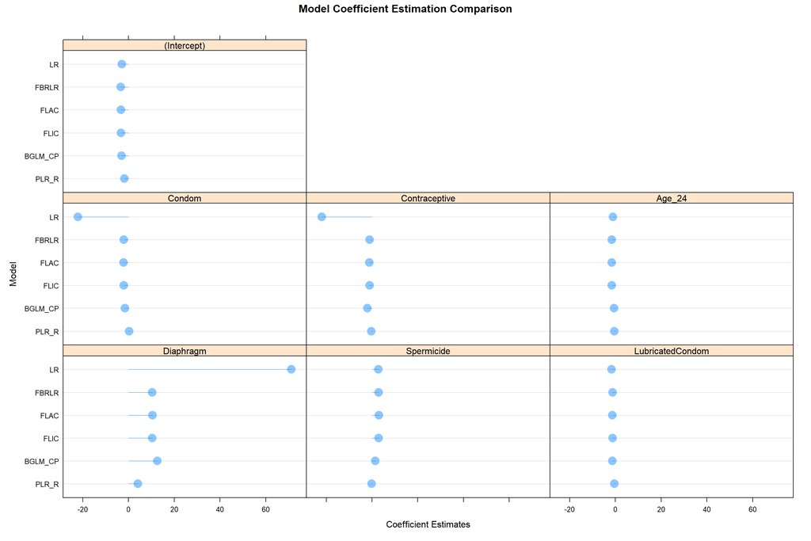

```r
(ROCCurveAUC_Plot <- dotplot(Model ~ Estimates | Coefficients,
                           data = RLRCoefficient_Summary,
                           main = "Model Coefficient Estimation Comparison",
                           ylab = "Model",
                           xlab = "Coefficient Estimates",
                           auto.key = list(adj = 1),
                           type=c("p", "h"),
                           origin = 0,
                           alpha = 0.45,
                           pch = 16,
                           cex = 2,
                           layout = c(3,3)))
```

# **2. Summary**

[figure not shown]

# **3. References**

**[Book]** [Applied Predictive Modeling](http://appliedpredictivemodeling.com/) by Max Kuhn and Kjell Johnson  
**[Book]** [An Introduction to Statistical Learning](https://www.statlearning.com/) by Gareth James, Daniela Witten, Trevor Hastie and Rob Tibshirani  
**[Book]** [Multivariate Data Visualization with R](http://lmdvr.r-forge.r-project.org/figures/figures.html) by Deepayan Sarkar  
**[Book]** [Machine Learning](https://bookdown.org/ssjackson300/Machine-Learning-Lecture-Notes/) by Samuel Jackson  
**[Book]** [Data Modeling Methods](https://bookdown.org/larget_jacob/data-modeling-methods/) by Jacob Larget  
**[Book]** [Introduction to R and Statistics](https://saestatsteaching.tech/) by University of Western Australia  
**[Book]** [Feature Engineering and Selection: A Practical Approach for Predictive Models](http://www.feat.engineering/index.html) by Max Kuhn and Kjell Johnson  
**[Book]** [Introduction to Regression Methods for Public Health Using R](https://www.bookdown.org/rwnahhas/RMPH/) by Ramzi Nahhas  
**[Book]** [Introduction to Research Methods](https://bookdown.org/ejvanholm/Textbook/) by Eric van Holm  
**[R Package]** [AppliedPredictiveModeling](https://cran.r-project.org/web//packages/AppliedPredictiveModeling/AppliedPredictiveModeling.pdf) by Max Kuhn  
**[R Package]** [caret](https://topepo.github.io/caret/index.html) by Max Kuhn  
**[R Package]** [rpart](https://mran.microsoft.com/web/packages/rpart/rpart.pdf) by Terry Therneau and Beth Atkinson  
**[R Package]** [lattice](https://cran.r-project.org/web/packages/lattice/lattice.pdf) by Deepayan Sarkar  
**[R Package]** [dplyr](https://cran.r-project.org/web/packages/dplyr/index.html/) by Hadley Wickham  
**[R Package]** [moments](https://cran.r-project.org/web/packages/moments/index.html) by Lukasz Komsta and Frederick  
**[R Package]** [skimr](https://cran.r-project.org/web/packages/skimr/skimr.pdf) by Elin Waring  
**[R Package]** [RANN](https://cran.r-project.org/web/packages/RANN/RANN.pdf) by Sunil Arya, David Mount, Samuel Kemp and Gregory Jefferis  
**[R Package]** [corrplot](https://cran.r-project.org/web/packages/corrplot/corrplot.pdf) by Taiyun Wei  
**[R Package]** [tidyverse](https://cran.r-project.org/web/packages/tidyverse/tidyverse.pdf) by Hadley Wickham  
**[R Package]** [lares](https://cran.rstudio.com/web/packages/lares/lares.pdf) by Bernardo Lares  
**[R Package]** [DMwR](https://mran.microsoft.com/snapshot/2016-05-02/web/packages/DMwR/DMwR.pdf) by Luis Torgo  
**[R Package]** [gridExtra](https://cran.r-project.org/web/packages/gridExtra/gridExtra.pdf) by Baptiste Auguie and Anton Antonov  
**[R Package]** [rattle](https://cran.r-project.org/web/packages/rattle/rattle.pdf) by Graham Williams  
**[R Package]** [rpart.plot](https://cran.r-project.org/web/packages/rpart.plot/rpart.plot.pdf) by Stephen Milborrow  
**[R Package]** [RColorBrewer](https://cran.r-project.org/web//packages/RColorBrewer/RColorBrewer.pdf) by Erich Neuwirth  
**[R Package]** [stats](https://search.r-project.org/R/refmans/stats/html/00Index.html) by R Core Team  
**[R Package]** [pls](https://cran.r-project.org/web/packages/pls/pls.pdf) by Kristian Hovde Liland  
**[R Package]** [nnet](https://cran.r-project.org/web/packages/nnet/nnet.pdf) by Brian Ripley  
**[R Package]** [elasticnet](https://cran.r-project.org/web/packages/elasticnet/elasticnet.pdf) by Hui Zou  
**[R Package]** [earth](https://cran.r-project.org/web/packages/earth/earth.pdf) by Stephen Milborrow  
**[R Package]** [party](https://cran.r-project.org/web/packages/party/party.pdf) by Torsten Hothorn  
**[R Package]** [kernlab](https://cran.r-project.org/web/packages/kernlab/kernlab.pdf) by Alexandros Karatzoglou  
**[R Package]** [randomForest](https://cran.r-project.org/web/packages/randomForest/randomForest.pdf) by Andy Liaw  
**[R Package]** [pROC](https://cran.r-project.org/web/packages/pROC/pROC.pdf) by Xavier Robin  
**[R Package]** [mda](https://cran.r-project.org/web/packages/mda/mda.pdf) by Trevor Hastie  
**[R Package]** [klaR](https://cran.r-project.org/web/packages/klaR/klaR.pdf) by Christian Roever, Nils Raabe, Karsten Luebke, Uwe Ligges, Gero Szepannek, Marc Zentgraf and David Meyer  
**[R Package]** [pamr](https://cran.r-project.org/web/packages/pamr/pamr.pdf) by Trevor Hastie, Rob Tibshirani, Balasubramanian Narasimhan and Gil Chu  
**[R Package]** [OptimalCutpoints](https://cran.r-project.org/web/packages/OptimalCutpoints/OptimalCutpoints.pdf) by Monica Lopez-Raton and Maria Xose Rodriguez-Alvarez  
**[R Package]** [broom](https://cran.r-project.org/web/packages/broom/broom.pdf) by Simon Couch  
**[R Package]** [PRROC](https://cran.r-project.org/web/packages/PRROC/PRROC.pdf) by Jan Grau and Jens Keilwagen  
**[R Package]** [ggpubr](https://cran.microsoft.com/snapshot/2022-04-13/web/packages/ggpubr/ggpubr.pdf) by Alboukadel Kassambara  
**[R Package]** [Hmisc](https://cran.r-project.org/web/packages/Hmisc/Hmisc.pdf) by Frank Harrell  
**[R Package]** [logistf](https://cran.r-project.org/web/packages/logistf/logistf.pdf) by Georg Heinze  
**[R Package]** [arm](https://cran.r-project.org/web/packages/arm/arm.pdf) by Yu-Sung Su  
**[R Package]** [glmnet](https://cran.r-project.org/web/packages/glmnet/glmnet.pdf) by Trevor Hastie  
**[Article]** [The caret Package](https://topepo.github.io/caret/index.html) by Max Kuhn  
**[Article]** [A Short Introduction to the caret Package](https://cran.r-project.org/web/packages/caret/vignettes/caret.html) by Max Kuhn  
**[Article]** Caret Package – A Practical Guide to Machine Learning in R by Selva Prabhakaran  
**[Article]** [Tuning Machine Learning Models Using the Caret R Package](https://machinelearningmastery.com/tuning-machine-learning-models-using-the-caret-r-package/) by Jason Brownlee  
**[Article]** [Lattice Graphs](http://www.sthda.com/english/wiki/lattice-graphs) by Alboukadel Kassambara

**[Article]** [What is Complete or Quasi-Complete Separation in Logistic/Probit Regression and How Do We Deal with Them](https://stats.oarc.ucla.edu/other/mult-pkg/faq/general/faqwhat-is-complete-or-quasi-complete-separation-in-logisticprobit-regression-and-how-do-we-deal-with-them/) by UCLA Advanced Research Computing Group  
**[Article]** [What Is Complete Separation in Binary Logistic Regression?](https://blog.minitab.com/en/starting-out-with-statistical-software/what-is-complete-separation-in-binary-logistic-regression) by Eric Heckman  
**[Article]** [Separation and Convergence Issues in Logistic Regression](https://cscu.cornell.edu/wp-content/uploads/82_lgsbias.pdf) by Cornell Statistical Consulting Unit  
**[Article]** [Firth Logistic Regression](https://www.r-bloggers.com/2010/11/example-8-15-firth-logistic-regression/) by Ken Kleinman  
**[Article]** [Penalized Logistic Regression Essentials in R: Ridge, Lasso and Elastic Net](http://sthda.com/english/articles/36-classification-methods-essentials/149-penalized-logistic-regression-essentials-in-r-ridge-lasso-and-elastic-net/) by Alboukadel Kassambara  
**[Article]** [Correcting the Quasi-complete Separation Issue in Logistic Regression Models](https://support.sas.com/resources/papers/proceedings16/10220-2016.pdf) by Xinghe Lu  
**[Article]** [An Introduction to glmnet](https://glmnet.stanford.edu/articles/glmnet.html) by Trevor Hastie, Junyang Qian and Kenneth Tay  
**[Article]** [Choosing Hyperparameters in Penalized Regression](https://privefl.github.io/blog/choosing-hyper-parameters-in-penalized-regression/) by Florian Prive  
**[Publication]** [The Origins of Logistic Regression](http://dx.doi.org/10.2139/ssrn.360300) by JS Cramer (Econometrics eJournal)  
**[Publication]** [Separation in Logistic Regression: Causes, Consequences, and Control](https://academic.oup.com/aje/article/187/4/864/4084405?login=false) by Mohammad Ali Mansournia, Angelika Geroldinger, Sander Greenland and Georg Heinze (American Journal of Epidemiology)  
**[Publication]** [Dealing with Separation in Logistic Regression Models](https://www.cambridge.org/core/journals/political-analysis/article/abs/dealing-with-separation-in-logistic-regression-models/E2F30195EFFD5F79A9B27ACA5107922F) by Carlisle Rainey (Political Analysis)  
**[Publication]** [Bias Reduction of Maximum Likelihood Estimates](https://academic.oup.com/biomet/article-abstract/80/1/27/228364?login=false) by David Firth (Biometrika)  
**[Publication]** [A Solution to the Problem of Separation in Logistic Regression](https://onlinelibrary.wiley.com/doi/10.1002/sim.1047) by Georg Heinze and Michael Schemper (Statistics in Medicine)  
**[Publication]** [A Comparative Investigation of Methods for Logistic Regression with Separated or Nearly Separated Data](https://onlinelibrary.wiley.com/doi/10.1002/sim.2687) by Georg Heinze (Statistics in Medicine)  
**[Publication]** [Confidence Intervals After Multiple Imputation: Combining Profile Likelihood Information from Logistic Regressions](https://onlinelibrary.wiley.com/doi/10.1002/sim.5899) by Georg Heinze, Meinhard Ploner and Jan Beyea (Statistics in Medicine)  
**[Publication]** [Firth’s Logistic Regression with Rare Events: Accurate Effect Estimates and Predictions?](https://onlinelibrary.wiley.com/doi/10.1002/sim.7273) by Rainer Puhr, Georg Heinze, Mariana Nold, Lara Lusa and Angelika Geroldinger (Statistics in Medicine)  
**[Publication]** [A Method for Computing Profile-Likelihood Based Confidence Intervals](https://rss.onlinelibrary.wiley.com/doi/abs/10.2307/2347496) by DJ Venzon and SH Moolgavkar (Applied Statistics)  
**[Publication]** [A Weakly Informative Default Prior Distribution For Logistic And Other Regression Models](http://www.stat.columbia.edu/~gelman/research/published/priors11.pdf) by Andrew Gelman, Aleks Jakulin, Maria Grazia Pittau and Yu-Sung Su (The Annals of Applied Statistics)  
**[Publication]** [Ridge Regression: Biased Estimation for Non-Orthogonal Problems](https://www.tandfonline.com/doi/abs/10.1080/00401706.1970.10488634) by Art Hoerl and Robert Kennard (Technometrics)  
**[Course]** [Applied Data Mining and Statistical Learning](https://online.stat.psu.edu/stat508/) by Penn State Eberly College of Science